# Problem Statement:

#### DurationOfPitch

```python
tourismDf[tourismDf.DurationOfPitch.isna()].head()
```

|  | ProdTaken | Age | TypeofContact | CityTier | DurationOfPitch | Occupation | Gender | NumberOfPersonVisiting | NumberOfFollowups | ProductPitched | PreferredPropertyStar | MaritalStatus | NumberOfTrips | Passport | PitchSatisfactionScore | OwnCar | NumberOfChildrenVisiting | Designation | MonthlyIncome |
| --- | --- | --- | --- | --- | --- | --- | --- | --- | --- | --- | --- | --- | --- | --- | --- | --- | --- | --- | --- |
| 46 | 0 | 34.0 | Company Invited | 3 | NaN | Small Business | Male | 3 | 3.0 | Deluxe | 3.0 | Single | 1.0 | 0 | 5 | 1 | 1.0 | Manager | 19568.0 |
| 75 | 0 | 31.0 | Self Enquiry | 1 | NaN | Salaried | Female | 3 | 3.0 | Deluxe | 3.0 | Single | 2.0 | 0 | 5 | 0 | 1.0 | Manager | NaN |
| 76 | 0 | 35.0 | Self Enquiry | 3 | NaN | Small Business | Male | 2 | 4.0 | Deluxe | 5.0 | Single | 1.0 | 0 | 2 | 0 | 1.0 | Manager | NaN |
| 84 | 0 | 34.0 | Self Enquiry | 1 | NaN | Small Business | Male | 3 | 3.0 | Deluxe | 4.0 | Divorced | 2.0 | 0 | 5 | 0 | 0.0 | Manager | NaN |
| 103 | 0 | 34.0 | Self Enquiry | 1 | NaN | Salaried | Female | 2 | 3.0 | Deluxe | 3.0 | Single | 2.0 | 0 | 3 | 1 | 0.0 | Manager | 19809.0 |

```python
tourismDf.DurationOfPitch = tourismDf.DurationOfPitch.fillna(tourismDf.DurationOfPitch.mean())
tourismDf.DurationOfPitch.isna().sum()
```

```
0
```

#### TypeofContact Field

```python
tourismDf.TypeofContact.unique()
```

```
['Self Enquiry', 'Company Invited', NaN]
Categories (2, object): ['Self Enquiry', 'Company Invited']
```

```python
tourismDf.TypeofContact.isna().sum()
```

```
25
```

There are 25 NaN values in the column, let us figure out how to replace these missing values.

```python
tourismDf.TypeofContact.value_counts(normalize=True)
```

```
Self Enquiry       0.708205
Company Invited    0.291795
Name: TypeofContact, dtype: float64
```

Since a majority of the customers have come through self inquiry, let us replace the missing values with 'Self Enquiry'

```python
tourismDf.TypeofContact = tourismDf.TypeofContact.fillna('Self Enquiry')
tourismDf.TypeofContact.isna().sum()
```

```
0
```

#### PreferredPropertyStar Field

```python
tourismDf.PreferredPropertyStar.unique()
```

```
[3.0, 4.0, 5.0, NaN]
Categories (3, float64): [3.0, 4.0, 5.0]
```

```python
tourismDf.PreferredPropertyStar.isna().sum()
```

```
26
```

There are 26 missing values in the column `PreferredPropertyStar`, let us figure out how to replace these missing values.

```python
tourismDf.PreferredPropertyStar.value_counts(normalize=True)
```

```
3.0    0.615590
5.0    0.196627
4.0    0.187783
Name: PreferredPropertyStar, dtype: float64
```

Since a majority of the customers prefer 3 star property, let us replace the missing values with 3

```python
tourismDf.PreferredPropertyStar = tourismDf.PreferredPropertyStar.fillna(3)
tourismDf.PreferredPropertyStar.isna().sum()
```

```
0
```

```python
tourismDf.PreferredPropertyStar.unique()
```

```
[3.0, 4.0, 5.0]
Categories (3, float64): [3.0, 4.0, 5.0]
```

```python
tourismDf.PreferredPropertyStar = tourismDf.PreferredPropertyStar.astype('int64')
```

Since the property star has only integer values, let us convert the type from float to int for better interpretation.

#### NumberOfFollowups field

```python
tourismDf[tourismDf.NumberOfFollowups.isna()].head()
```

|  | ProdTaken | Age | TypeofContact | CityTier | DurationOfPitch | Occupation | Gender | NumberOfPersonVisiting | NumberOfFollowups | ProductPitched | PreferredPropertyStar | MaritalStatus | NumberOfTrips | Passport | PitchSatisfactionScore | OwnCar | NumberOfChildrenVisiting | Designation | MonthlyIncome |
| --- | --- | --- | --- | --- | --- | --- | --- | --- | --- | --- | --- | --- | --- | --- | --- | --- | --- | --- | --- |
| 79 | 0 | 46.0 | Self Enquiry | 2 | 11.0 | Small Business | Male | 3 | NaN | Deluxe | 4 | Married | 1.0 | 1 | 5 | 0 | 1.0 | Manager | 20021.0 |
| 94 | 0 | 32.0 | Self Enquiry | 3 | 12.0 | Small Business | Male | 2 | NaN | Deluxe | 3 | Single | 2.0 | 0 | 5 | 1 | 0.0 | Manager | 20010.0 |
| 96 | 0 | 24.0 | Self Enquiry | 3 | 9.0 | Salaried | Female | 2 | NaN | Deluxe | 3 | Divorced | 1.0 | 0 | 4 | 1 | 0.0 | Manager | 19999.0 |
| 122 | 1 | 56.0 | Self Enquiry | 1 | 20.0 | Salaried | Female | 3 | NaN | Basic | 4 | Divorced | 1.0 | 1 | 5 | 1 | 1.0 | Executive | 19963.0 |
| 135 | 0 | 36.0 | Self Enquiry | 1 | 12.0 | Small Business | Male | 2 | NaN | Deluxe | 4 | Married | 7.0 | 0 | 4 | 1 | 1.0 | Manager | 19941.0 |

```python
tourismDf['NumberOfFollowups']=tourismDf.groupby(['TypeofContact','Occupation','CityTier','Gender','ProductPitched','MaritalStatus','PreferredPropertyStar','Passport','OwnCar','Designation'])['NumberOfFollowups'].apply(lambda x:x.fillna(x.median()))
tourismDf.NumberOfFollowups.isna().sum()
```

```
3
```

```python
tourismDf['NumberOfFollowups']=tourismDf.groupby(['TypeofContact','Occupation','CityTier','Gender','ProductPitched','MaritalStatus','PreferredPropertyStar','Passport','OwnCar','Designation'])['NumberOfFollowups'].apply(lambda x:x.fillna(x.median()))
tourismDf.NumberOfFollowups.isna().sum()
```

```
3
```

```python
tourismDf[tourismDf.NumberOfFollowups.isna()]
```

|  | ProdTaken | Age | TypeofContact | CityTier | DurationOfPitch | Occupation | Gender | NumberOfPersonVisiting | NumberOfFollowups | ProductPitched | PreferredPropertyStar | MaritalStatus | NumberOfTrips | Passport | PitchSatisfactionScore | OwnCar | NumberOfChildrenVisiting | Designation | MonthlyIncome |
| --- | --- | --- | --- | --- | --- | --- | --- | --- | --- | --- | --- | --- | --- | --- | --- | --- | --- | --- | --- |
| 881 | 0 | 32.0 | Company Invited | 1 | 8.0 | Salaried | Female | 2 | NaN | Deluxe | 3 | Single | 5.0 | 1 | 5 | 1 | 1.0 | Manager | 19998.0 |
| 1244 | 0 | 30.0 | Company Invited | 1 | 8.0 | Large Business | Female | 3 | NaN | Basic | 5 | Single | 1.0 | 0 | 3 | 0 | 1.0 | Executive | 19968.0 |
| 2351 | 0 | 32.0 | Company Invited | 1 | 8.0 | Salaried | Female | 2 | NaN | Deluxe | 3 | Single | 5.0 | 1 | 5 | 1 | 0.0 | Manager | 19998.0 |

```python
tourismDf['NumberOfFollowups']=tourismDf.groupby(['TypeofContact','CityTier','Gender'])['NumberOfFollowups'].apply(lambda x:x.fillna(x.median()))
tourismDf.NumberOfFollowups.isna().sum()
```

```
0
```

```python
tourismDf.NumberOfFollowups = tourismDf.NumberOfFollowups.astype('int64')
```

#### NumberOfChildrenVisiting field

```python
tourismDf['NumberOfChildrenVisiting'] = tourismDf.groupby(['TypeofContact','Occupation','CityTier','Gender','ProductPitched','MaritalStatus','PreferredPropertyStar','Passport','OwnCar','Designation'])['NumberOfChildrenVisiting'].apply(lambda x:x.fillna(x.median()))
tourismDf.NumberOfChildrenVisiting.isna().sum()
```

```
12
```

```python
tourismDf['NumberOfChildrenVisiting']=tourismDf.groupby(['Gender','ProductPitched','MaritalStatus','PreferredPropertyStar','Passport','OwnCar'])['NumberOfChildrenVisiting'].apply(lambda x:x.fillna(x.median()))
tourismDf.NumberOfChildrenVisiting.isna().sum()
```

```
7
```

```python
tourismDf.NumberOfChildrenVisiting.mean()
```

```
1.1834665027658267
```

```python
tourismDf['NumberOfChildrenVisiting'] = tourismDf.NumberOfChildrenVisiting.fillna(tourismDf.NumberOfChildrenVisiting.mean())
tourismDf.NumberOfChildrenVisiting.isna().sum()
```

```
0
```

```python
tourismDf['NumberOfChildrenVisiting']  = tourismDf['NumberOfChildrenVisiting'].astype(int)
```

```python
tourismDf.info()
```

```
<class 'pandas.core.frame.DataFrame'>
RangeIndex: 4888 entries, 0 to 4887
Data columns (total 19 columns):
 #   Column                    Non-Null Count  Dtype
---  ------                    --------------  -----
 0   ProdTaken                 4888 non-null   int64
 1   Age                       4662 non-null   float64
 2   TypeofContact             4888 non-null   category
 3   CityTier                  4888 non-null   category
 4   DurationOfPitch           4888 non-null   float64
 5   Occupation                4888 non-null   category
 6   Gender                    4888 non-null   category
 7   NumberOfPersonVisiting    4888 non-null   int64
 8   NumberOfFollowups         4888 non-null   int64
 9   ProductPitched            4888 non-null   category
 10  PreferredPropertyStar     4888 non-null   int64
 11  MaritalStatus             4888 non-null   category
 12  NumberOfTrips             4748 non-null   float64
 13  Passport                  4888 non-null   category
 14  PitchSatisfactionScore    4888 non-null   category
 15  OwnCar                    4888 non-null   category
 16  NumberOfChildrenVisiting  4888 non-null   int64
 17  Designation               4888 non-null   category
 18  MonthlyIncome             4655 non-null   float64
dtypes: category(10), float64(4), int64(5)
memory usage: 393.0 KB
```

```python
tourismDf['NumberOfChildrenVisiting'].unique()
```

```
array([0, 2, 1, 3])
```

```python
tourismDf[tourismDf.NumberOfChildrenVisiting >= tourismDf.NumberOfPersonVisiting]
```

|  | ProdTaken | Age | TypeofContact | CityTier | DurationOfPitch | Occupation | Gender | NumberOfPersonVisiting | NumberOfFollowups | ProductPitched | PreferredPropertyStar | MaritalStatus | NumberOfTrips | Passport | PitchSatisfactionScore | OwnCar | NumberOfChildrenVisiting | Designation | MonthlyIncome |
| --- | --- | --- | --- | --- | --- | --- | --- | --- | --- | --- | --- | --- | --- | --- | --- | --- | --- | --- | --- |

```python
tourismDf.loc[(tourismDf.NumberOfChildrenVisiting >= tourismDf.NumberOfPersonVisiting),['NumberOfChildrenVisiting']] = 0
tourismDf.loc[(tourismDf.NumberOfChildrenVisiting >= tourismDf.NumberOfPersonVisiting)]
```

|  | ProdTaken | Age | TypeofContact | CityTier | DurationOfPitch | Occupation | Gender | NumberOfPersonVisiting | NumberOfFollowups | ProductPitched | PreferredPropertyStar | MaritalStatus | NumberOfTrips | Passport | PitchSatisfactionScore | OwnCar | NumberOfChildrenVisiting | Designation | MonthlyIncome |
| --- | --- | --- | --- | --- | --- | --- | --- | --- | --- | --- | --- | --- | --- | --- | --- | --- | --- | --- | --- |

#### NumberOfTrips field

```python
tourismDf['NumberOfTrips']=tourismDf.groupby(['TypeofContact','Occupation','CityTier','Gender','ProductPitched','MaritalStatus','PreferredPropertyStar','Passport','OwnCar','Designation'])['NumberOfTrips'].apply(lambda x:x.fillna(x.median()))
tourismDf.NumberOfTrips.isna().sum()
```

```
0
```

```python
tourismDf['NumberOfTrips']=tourismDf.groupby(['TypeofContact','Occupation','CityTier','Gender','ProductPitched','MaritalStatus','PreferredPropertyStar','Passport','OwnCar','Designation'])['NumberOfTrips'].apply(lambda x:x.fillna(x.median()))
tourismDf.NumberOfTrips.isna().sum()
```

```
0
```

```python
tourismDf['NumberOfTrips']=tourismDf.groupby(['TypeofContact','CityTier','Gender'])['NumberOfTrips'].apply(lambda x:x.fillna(x.median()))
tourismDf.NumberOfTrips.isna().sum()
```

```
0
```

```python
tourismDf.NumberOfTrips = tourismDf.NumberOfTrips.astype(int)
```

#### Age Field

```python
tourismDf.Age.isna().sum()
```

```
226
```

```python
tourismDf.groupby(['NumberOfTrips','Passport','PitchSatisfactionScore','OwnCar'])['Age'].median()
```

```
NumberOfTrips  Passport  PitchSatisfactionScore  OwnCar
1              0         1                       0         33.0
                                                 1         39.0
                         2                       0         37.0
                                                 1         37.0
                         3                       0         36.0
                                                           ...
22             1         3                       1          NaN
                         4                       0          NaN
                                                 1          NaN
                         5                       0          NaN
                                                 1          NaN
Name: Age, Length: 240, dtype: float64
```

```python
tourismDf['Age']=tourismDf.groupby(['NumberOfTrips','Passport','PitchSatisfactionScore','OwnCar'])['Age'].apply(lambda x:x.fillna(x.median()))
```

```python
tourismDf['Age']=tourismDf.Age.fillna(tourismDf.Age.median())
```

```python
tourismDf.Age.unique()
```

```
array([41. , 49. , 37. , 33. , 40. , 32. , 59. , 30. , 38. , 36. , 35. ,
       42. , 31. , 34. , 28. , 29. , 22. , 53. , 41.5, 21. , 44. , 46. ,
       39. , 24. , 43. , 50. , 27. , 26. , 48. , 36.5, 40.5, 55. , 45. ,
       56. , 23. , 51. , 54. , 58. , 20. , 25. , 19. , 57. , 52. , 47. ,
       18. , 50.5, 42.5, 60. , 43.5, 33.5, 34.5, 32.5, 61. ])
```

```python
tourismDf.Age.describe()
```

```
count    4888.000000
mean       37.541633
std         9.134371
min        18.000000
25%        31.000000
50%        36.000000
75%        43.000000
max        61.000000
Name: Age, dtype: float64
```

```python
tourismDf.Age = tourismDf.Age.astype(int)
```

Convert the datatype of Age column from float to int for better interpretation

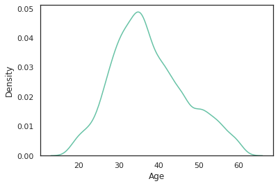

```python
sns.kdeplot(data=tourismDf,x='Age')
plt.show()
```

**Observations:**

- There are more people in the Age group 30 to 40. Let us consider bining the Age carefully see how it works.

#### Binning Age Field

```python
tourismDf['Agebin'] = pd.cut(tourismDf['Age'], bins = [15,25, 30, 40, 50, 70], labels = ['15-25','26-30', '31-40', '41-50', '51-70'])
```

```python
tourismDf.Agebin.value_counts()
```

```
31-40    2126
41-50    1096
26-30     770
51-70     549
15-25     347
Name: Agebin, dtype: int64
```

#### MontlyIncome

```python
tourismDf["MonthlyIncome"]=tourismDf.groupby(["Occupation",'Designation','Gender'])["MonthlyIncome"].apply(
    lambda x: x.fillna(x.median())
)
```

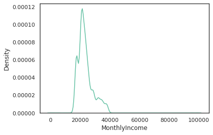

```python
sns.kdeplot(data=tourismDf,x='MonthlyIncome')
plt.show()
```

```python
tourismDf.MonthlyIncome.describe()
```

```
count     4888.000000
mean     23543.855769
std       5267.651455
min       1000.000000
25%      20438.250000
50%      22393.000000
75%      25424.750000
max      98678.000000
Name: MonthlyIncome, dtype: float64
```

#### Binning MonthlyIncome Field

Adding a new column, converting the MonthlyIncome value into bins to understand the customers in different income range

```python
tourismDf['Incomebin'] = pd.cut(tourismDf['MonthlyIncome'], bins = [0,15000,20000, 25000, 30000,35000,50000,100000], labels = ['Below15K', '15K-20k', '20K-25K', '25K-30K','30K-35K','35K-50K','50K-100K'])
```

```python
tourismDf.Incomebin.value_counts()
```

```
20K-25K     2490
15K-20k     1038
25K-30K      768
30K-35K      382
35K-50K      206
50K-100K       2
Below15K       2
Name: Incomebin, dtype: int64
```

```python
tourismDf.Agebin.unique()
```

```
['41-50', '31-40', '51-70', '26-30', '15-25']
Categories (5, object): ['15-25' < '26-30' < '31-40' < '41-50' < '51-70']
```